# Project 1: Wrangling, Exploration, Visualization

SDS322E

## Data Wrangling, Exploration, Visualization

Jazzalyn Zou

#### Introduction

The two data sets I chose were Body and Workout. In my Body data set, I downloaded data from my apple watch of my body during a workout which includes information about my heart rates, basal energy, and stand time. For my Workout data set, I also downloaded it from my apple watch and this includes the types of workouts I do and how long I do them for, heart rates, total and active energy, distances walked and steps walked.I picked these data sets because I enjoy working out and being active so being able to work with these number and analyze my own information is extremely interesting to me.

```r
library(tidyverse)
Body <- read_csv("Body.csv")
Workout <- read_csv("Workout.csv")
```

#### Tidying: Reshaping

```r
Workout <- Workout %>% pivot_wider(names_from = Type, values_from = "Duration")

glimpse(Body)
```

```
## Rows: 89
## Columns: 8
## $ Date                   <dttm> 2021-07-29, 2021-07-30, 2021-07-31, 2021-08-0…
## $ Stand_Time             <dbl> 60, 112, 61, 59, 31, 88, 73, 54, 86, 63, 79, 4…
## $ Basal_Energy_Burned    <dbl> 1548, 1545, 1491, 1551, 1474, 1568, 1446, 1449…
## $ Heart_Rate_Min         <dbl> 68.00, 55.00, 54.00, 52.00, 71.00, 57.31, 54.0…
## $ Heart_Rate_Max         <dbl> 175, 168, 115, 140, 162, 157, 172, 182, 168, 1…
## $ Heart_Rate_Avg         <dbl> 133.09, 119.43, 76.94, 99.54, 118.38, 99.55, 1…
## $ Heart_Rate_Variability <dbl> 41.19, 17.44, 65.43, 38.78, NA, 51.54, NA, NA,…
## $ Resting_Heart_Rate     <dbl> NA, 65, 58, 53, 74, 62, NA, 75, NA, 63, 60, NA…
```

```r
glimpse(Workout)
```

```
## Rows: 77
## Columns: 23
## $ Start                           <dttm> 2021-10-26 17:30:00, 2021-10-24 18:2…
## $ End                             <dttm> 2021-10-26 18:26:00, 2021-10-24 19:0…
## $ Total_Energy                    <dbl> 261.40, 261.43, 239.69, 354.69, 195.4…
## $ Active_Energy                   <dbl> 179.97, 199.73, 172.47, 272.66, 146.3…
## $ Max_Heart_Rate                  <dbl> 142, 160, 164, 172, 141, 175, 142, 16…
## $ Avg_Heart_Rate                  <dbl> 108.17, 133.02, 107.95, 110.21, 105.0…
## $ Distance                        <dbl> NA, 1.270, 0.426, NA, NA, NA, NA, NA,…
## $ Avg_Speed                       <dbl> NA, 1.970, 0.587, NA, NA, NA, NA, NA,…
## $ Step_Count                      <dbl> 1320, 2917, 944, 2014, 405, 624, 1781…
## $ Step_Cadence                    <dbl> 0.390, 1.260, 0.361, 0.473, 0.158, 0.…
## $ Swimming_Stroke_Count           <dbl> NA, NA, NA, NA, NA, NA, NA, NA, NA, N…
## $ Swim_Stoke_Cadence              <dbl> NA, NA, NA, NA, NA, NA, NA, NA, NA, N…
## $ Flights_Climbed                 <dbl> NA, NA, NA, NA, NA, NA, NA, NA, NA, N…
## $ Elevation_Ascended              <dbl> NA, NA, NA, NA, NA, NA, NA, NA, NA, N…
## $ Elevation_Descended             <lgl> NA, NA, NA, NA, NA, NA, NA, NA, NA, N…
## $ `Traditional Strength Training` <time> 00:56:26,       NA,       NA, 01:10:…
## $ Walking                         <time>       NA, 00:38:39,       NA,       …
## $ Racquetball                     <time>       NA,       NA, 00:43:33,       …
## $ `Core Training`                 <time>       NA,       NA,       NA,       …
## $ Running                         <time> NA, NA, NA, NA, NA, NA, NA, NA, NA, …
## $ Swimming                        <time> NA, NA, NA, NA, NA, NA, NA, NA, NA, …
## $ Other                           <time> NA, NA, NA, NA, NA, NA, NA, NA, NA, …
## $ `Stair Climbing`                <time> NA, NA, NA, NA, NA, NA, NA, NA, NA, …
```

All my workouts were listed under one column and instead I wanted to seperate them based on the type of workout. I did this pivoting wider.

#### Joining/Merging

```r
Workout <- Workout %>% rename(Date = Start) %>% select(-End) %>%
    mutate_at(c("Date"), as.character) %>% mutate_at("Date",
    str_replace, " \\d\\d:\\d\\d:\\d\\d", "")

Body <- Body %>% mutate_at(c("Date"), as.character)

Body %>% summarize(n(), n_distinct(Date))
```

```
## # A tibble: 1 x 2
##   `n()` `n_distinct(Date)`
##   <int>              <int>
## 1    89                 89
```

```r
Workout %>% summarize(n(), n_distinct(Workout))
```

```
## # A tibble: 1 x 2
##   `n()` `n_distinct(Workout)`
##   <int>                 <int>
## 1    77                    77
```

```r
Combined <- full_join(Body, Workout, by = "Date")
anti_join(Body, Workout, by = "Date")
```

```
## # A tibble: 30 x 8
##    Date  Stand_Time Basal_Energy_Bu… Heart_Rate_Min Heart_Rate_Max
##    <chr>      <dbl>            <dbl>          <dbl>          <dbl>
##  1 2021…         61             1491             54            115
##  2 2021…         31             1474             71            162
##  3 2021…         63             1458             60            127
##  4 2021…         NA             1425             NA             NA
##  5 2021…        121             1512             53            163
##  6 2021…        116             1461             52            173
##  7 2021…        123             1502             54            120
##  8 2021…        110             1550             59            118
##  9 2021…         41             1497             54             99
## 10 2021…         65             1379             63            145
## # … with 20 more rows, and 3 more variables: Heart_Rate_Avg <dbl>,
## #   Heart_Rate_Variability <dbl>, Resting_Heart_Rate <dbl>
```

```r
inner_join(Body, Workout, by = "Date")
```

```
## # A tibble: 77 x 29
##    Date  Stand_Time Basal_Energy_Bu… Heart_Rate_Min Heart_Rate_Max
##    <chr>      <dbl>            <dbl>          <dbl>          <dbl>
##  1 2021…         60             1548           68              175
##  2 2021…         60             1548           68              175
##  3 2021…         60             1548           68              175
##  4 2021…        112             1545           55              168
##  5 2021…        112             1545           55              168
##  6 2021…         59             1551           52              140
##  7 2021…         59             1551           52              140
##  8 2021…         88             1568           57.3            157
##  9 2021…         73             1446           54              172
## 10 2021…         73             1446           54              172
## # … with 67 more rows, and 24 more variables: Heart_Rate_Avg <dbl>,
## #   Heart_Rate_Variability <dbl>, Resting_Heart_Rate <dbl>, Total_Energy <dbl>,
## #   Active_Energy <dbl>, Max_Heart_Rate <dbl>, Avg_Heart_Rate <dbl>,
## #   Distance <dbl>, Avg_Speed <dbl>, Step_Count <dbl>, Step_Cadence <dbl>,
## #   Swimming_Stroke_Count <dbl>, Swim_Stoke_Cadence <dbl>,
## #   Flights_Climbed <dbl>, Elevation_Ascended <dbl>, Elevation_Descended <lgl>,
## #   `Traditional Strength Training` <time>, Walking <time>, Racquetball <time>,
## #   `Core Training` <time>, Running <time>, Swimming <time>, Other <time>,
## #   `Stair Climbing` <time>
```

```r
# anti_join(Workout, Body, by = 'Date')
```

#### Wrangling

```r
Combined <- Combined %>% select(-Step_Cadence, -Swimming_Stroke_Count,
    -Swim_Stoke_Cadence, -Flights_Climbed, -Elevation_Ascended,
    -Elevation_Descended)

Combined <- Combined %>% mutate(Heart_Rate_Range = Heart_Rate_Max -
    Heart_Rate_Min)

Combined %>% filter(Basal_Energy_Burned == max(Basal_Energy_Burned)) %>%
    select(-Other)
```

```
## # A tibble: 1 x 23
##   Date  Stand_Time Basal_Energy_Bu… Heart_Rate_Min Heart_Rate_Max Heart_Rate_Avg
##   <chr>      <dbl>            <dbl>          <dbl>          <dbl>          <dbl>
## 1 2021…        143             1647             56            138           86.0
## # … with 17 more variables: Heart_Rate_Variability <dbl>,
## #   Resting_Heart_Rate <dbl>, Total_Energy <dbl>, Active_Energy <dbl>,
## #   Max_Heart_Rate <dbl>, Avg_Heart_Rate <dbl>, Distance <dbl>,
## #   Avg_Speed <dbl>, Step_Count <dbl>, `Traditional Strength Training` <time>,
## #   Walking <time>, Racquetball <time>, `Core Training` <time>, Running <time>,
## #   Swimming <time>, `Stair Climbing` <time>, Heart_Rate_Range <dbl>
```

```r
Combined %>% arrange(desc(Heart_Rate_Max))
```

```
## # A tibble: 107 x 24
##    Date  Stand_Time Basal_Energy_Bu… Heart_Rate_Min Heart_Rate_Max
##    <chr>      <dbl>            <dbl>          <dbl>          <dbl>
##  1 2021…        146             1429             50            193
##  2 2021…        158             1438             53            189
##  3 2021…        158             1438             53            189
##  4 2021…        146             1397             62            184
##  5 2021…         54             1449             54            182
##  6 2021…        134             1533             57            182
##  7 2021…         90             1369             66            182
##  8 2021…         84             1453             65            181
##  9 2021…         84             1453             65            181
## 10 2021…         84             1453             65            181
## # … with 97 more rows, and 19 more variables: Heart_Rate_Avg <dbl>,
## #   Heart_Rate_Variability <dbl>, Resting_Heart_Rate <dbl>, Total_Energy <dbl>,
## #   Active_Energy <dbl>, Max_Heart_Rate <dbl>, Avg_Heart_Rate <dbl>,
## #   Distance <dbl>, Avg_Speed <dbl>, Step_Count <dbl>, `Traditional Strength
## #   Training` <time>, Walking <time>, Racquetball <time>, `Core
## #   Training` <time>, Running <time>, Swimming <time>, Other <time>, `Stair
## #   Climbing` <time>, Heart_Rate_Range <dbl>
```

```r
Combined %>% group_by(Stand_Time) %>% summarize(n = n())
```

```
## # A tibble: 75 x 2
##    Stand_Time     n
##         <dbl> <int>
##  1          7     1
##  2          8     1
##  3         31     2
##  4         37     1
##  5         41     2
##  6         44     1
##  7         45     1
##  8         46     1
##  9         48     1
## 10         49     1
## # … with 65 more rows
```

```r
Combined %>% mutate(Date = str_replace(Date, "2021-", ""))
```

```
## # A tibble: 107 x 24
##    Date  Stand_Time Basal_Energy_Bu… Heart_Rate_Min Heart_Rate_Max
##    <chr>      <dbl>            <dbl>          <dbl>          <dbl>
##  1 07-29         60             1548           68              175
##  2 07-29         60             1548           68              175
##  3 07-29         60             1548           68              175
##  4 07-30        112             1545           55              168
##  5 07-30        112             1545           55              168
##  6 07-31         61             1491           54              115
##  7 08-01         59             1551           52              140
##  8 08-01         59             1551           52              140
##  9 08-02         31             1474           71              162
## 10 08-03         88             1568           57.3            157
## # … with 97 more rows, and 19 more variables: Heart_Rate_Avg <dbl>,
## #   Heart_Rate_Variability <dbl>, Resting_Heart_Rate <dbl>, Total_Energy <dbl>,
## #   Active_Energy <dbl>, Max_Heart_Rate <dbl>, Avg_Heart_Rate <dbl>,
## #   Distance <dbl>, Avg_Speed <dbl>, Step_Count <dbl>, `Traditional Strength
## #   Training` <time>, Walking <time>, Racquetball <time>, `Core
## #   Training` <time>, Running <time>, Swimming <time>, Other <time>, `Stair
## #   Climbing` <time>, Heart_Rate_Range <dbl>
```

```r
Combined %>% summarize(mean(Stand_Time, na.rm = T), sd(Stand_Time,
    na.rm = T), var(Stand_Time, na.rm = T), quantile(Stand_Time,
    na.rm = T), min(Stand_Time, na.rm = T), max(Stand_Time, na.rm = T),
    n_distinct(Stand_Time), n())
```

```
## # A tibble: 5 x 8
##   `mean(Stand_Tim… `sd(Stand_Time,… `var(Stand_Time… `quantile(Stand…
##              <dbl>            <dbl>            <dbl>            <dbl>
## 1             118.             55.9            3128.               7
## 2             118.             55.9            3128.              73
## 3             118.             55.9            3128.             118
## 4             118.             55.9            3128.             159.
## 5             118.             55.9            3128.             243
## # … with 4 more variables: `min(Stand_Time, na.rm = T)` <dbl>, `max(Stand_Time,
## #   na.rm = T)` <dbl>, `n_distinct(Stand_Time)` <int>, `n()` <int>
```

```r
Combined %>% summarize(mean(Resting_Heart_Rate, na.rm = T), sd(Resting_Heart_Rate,
    na.rm = T), var(Resting_Heart_Rate, na.rm = T), quantile(Resting_Heart_Rate,
    na.rm = T), min(Resting_Heart_Rate, na.rm = T), max(Resting_Heart_Rate,
    na.rm = T), n_distinct(Resting_Heart_Rate), n())
```

```
## # A tibble: 5 x 8
##   `mean(Resting_H… `sd(Resting_Hea… `var(Resting_He… `quantile(Resti…
##              <dbl>            <dbl>            <dbl>            <dbl>
## 1             60.8             6.54             42.8               53
## 2             60.8             6.54             42.8               57
## 3             60.8             6.54             42.8               59
## 4             60.8             6.54             42.8               63
## 5             60.8             6.54             42.8               86
## # … with 4 more variables: `min(Resting_Heart_Rate, na.rm = T)` <dbl>,
## #   `max(Resting_Heart_Rate, na.rm = T)` <dbl>,
## #   `n_distinct(Resting_Heart_Rate)` <int>, `n()` <int>
```

```r
Combined %>% summarize_all(function(x) sum(is.na(x)))
```

```
## # A tibble: 1 x 24
##    Date Stand_Time Basal_Energy_Bu… Heart_Rate_Min Heart_Rate_Max Heart_Rate_Avg
##   <int>      <int>            <int>          <int>          <int>          <int>
## 1     0          3                0              3              3              3
## # … with 18 more variables: Heart_Rate_Variability <int>,
## #   Resting_Heart_Rate <int>, Total_Energy <int>, Active_Energy <int>,
## #   Max_Heart_Rate <int>, Avg_Heart_Rate <int>, Distance <int>,
## #   Avg_Speed <int>, Step_Count <int>, `Traditional Strength Training` <int>,
## #   Walking <int>, Racquetball <int>, `Core Training` <int>, Running <int>,
## #   Swimming <int>, Other <int>, `Stair Climbing` <int>, Heart_Rate_Range <int>
```

```r
Combined <- Combined %>% group_by(Active_Energy) %>% mutate(Active_Energy_Scale = ifelse(Active_Energy >
    300, "high", ifelse(Active_Energy <= 300 & 200 <= Active_Energy,
    "med", "low")))

Combined %>% group_by(Active_Energy_Scale) %>% summarize(n())
```

```
## # A tibble: 4 x 2
##   Active_Energy_Scale `n()`
##   <chr>               <int>
## 1 high                   10
## 2 low                    28
## 3 med                    39
## 4 <NA>                   30
```

```r
minutes_to_hours <- function(Stand_Time) {
    Stand_Time_Hours <- (Stand_Time/60)
    return(Stand_Time_Hours)
}
Combined %>% mutate(Stand_Time = minutes_to_hours(Stand_Time))
```

```
## # A tibble: 107 x 25
## # Groups:   Active_Energy [78]
##    Date  Stand_Time Basal_Energy_Bu… Heart_Rate_Min Heart_Rate_Max
##    <chr>      <dbl>            <dbl>          <dbl>          <dbl>
##  1 2021…      1                 1548           68              175
##  2 2021…      1                 1548           68              175
##  3 2021…      1                 1548           68              175
##  4 2021…      1.87              1545           55              168
##  5 2021…      1.87              1545           55              168
##  6 2021…      1.02              1491           54              115
##  7 2021…      0.983             1551           52              140
##  8 2021…      0.983             1551           52              140
##  9 2021…      0.517             1474           71              162
## 10 2021…      1.47              1568           57.3            157
## # … with 97 more rows, and 20 more variables: Heart_Rate_Avg <dbl>,
## #   Heart_Rate_Variability <dbl>, Resting_Heart_Rate <dbl>, Total_Energy <dbl>,
## #   Active_Energy <dbl>, Max_Heart_Rate <dbl>, Avg_Heart_Rate <dbl>,
## #   Distance <dbl>, Avg_Speed <dbl>, Step_Count <dbl>, `Traditional Strength
## #   Training` <time>, Walking <time>, Racquetball <time>, `Core
## #   Training` <time>, Running <time>, Swimming <time>, Other <time>, `Stair
## #   Climbing` <time>, Heart_Rate_Range <dbl>, Active_Energy_Scale <chr>
```

```r
library(knitr)
library(gt)
table1 <- Combined %>% group_by(Active_Energy_Scale) %>% summarize_at(c(6,
    10), .funs = list(mean = mean, sd = sd)) %>% pivot_wider()
table1 %>% kable()
```

| Active_Energy_Scale | Heart_Rate_Avg_mean | Active_Energy_mean | Heart_Rate_Avg_sd | Active_Energy_sd |
| --- | --- | --- | --- | --- |
| high | 103.8070 | 337.318 | 5.958641 | 43.35224 |
| low | 101.0882 | 111.545 | 14.771088 | 57.54560 |
| med | 102.0131 | 241.231 | 11.038939 | 25.49141 |
| NA | NA | NA | NA | NA |

```r
table1 %>% gt %>% tab_header(title = md("**Summary Active Energy Scale**"))
```

**Summary Active Energy Scale**

| Active_Energy_Scale | Heart_Rate_Avg_mean | Active_Energy_mean | Heart_Rate_Avg_sd | Active_Energy_sd |
| --- | --- | --- | --- | --- |
| high | 103.8070 | 337.318 | 5.958641 | 43.35224 |
| low | 101.0882 | 111.545 | 14.771088 | 57.54560 |
| med | 102.0131 | 241.231 | 11.038939 | 25.49141 |
| NA | NA | NA | NA | NA |

I first used select to remove a couple of columns that had very little information which mostly had information about exercises I don’t commonly do I then used mutate to create a new column called Heart_Rate_Range that calculated the range between my Maximum Heart Rate and my Minimum Heart Rate. I then created a function that found my maximum basal energy burned which was 1647 calories in a day. I also removed the column Other in my dataset since it provided very little information about what workout I did and the time I did it for. Next I found my maximum heart rate during any workout which was 193 bpm. Next, I summarized my stand times to determine how many unqiue stand times I had and I had 75 unique times. Finally I removed “2021-” from the dates since I thought they were redundant.

Next, I created summary statistics for my variables. For Stand Time, I had a mean stand time of 118.35 with standard deviation of 55.93 minutes, with an IQR of min = 7 minutes, Q1 of 73 minutes, Median of 118 minutes, Q3 of 159 minutes and maximum of 243 minutes. For my resting heart rate, I had a mean of 60.84 bpm with standard deviation 6.54 bpm, with an IQR of min = 53 bpm, Q1 of 57 bpm, median of 59 bpm, Q3 63 bpm and a maximum of 86 bpm. There were 22 distinct rates for my resting heart rate. Next, I summarized the NAs to determine how many NAs were in each column. There were minimums of 0 in Date and Basal Energy Burned and maximum NAs in racquetball and stair climbing. I then grouped my numeric Active Calories into categories low, medium, high, which groups calories burned during an exercise above 300 as high, calories burned between 200-300 as medium and below 200 as low. After that, I summarized and saw that there were 10 distinct workouts that were high calories burned, 39 that were medium, 28 that were low, and 30 NAs. In addition, I changed my stand time from minutes to hours by using a function that I created and added it to the data set.

#### Visualizing

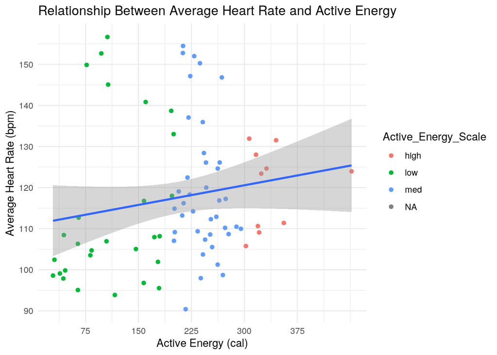

```r
Combined %>% ggplot(aes(x = Active_Energy, y = Avg_Heart_Rate)) +
    geom_point(aes(color = Active_Energy_Scale)) + geom_smooth(method = "lm") +
    xlab("Active Energy (cal)") + ylab("Average Heart Rate (bpm)") +
    ggtitle("Relationship Between Average Heart Rate and Active Energy") +
    theme_minimal() + scale_x_continuous(breaks = seq(0, 400,
    75)) + scale_y_continuous(breaks = seq(50, 200, 10))
```

This plot visualizes the relationship between Active Energy (cal) burned during an excercise and Average Heart Rate (bpm). I also color coded the points by my Active Energy Scale. I theorized a direct relationship between the two variables so that the more energy burned during an exercise the higher my average heart rate was. This is confirmed in my graph with the upward trend of my geom_smooth() which shows the trend line of the points. However, we also do see a lot of variation among the points especially in the low and medium range.

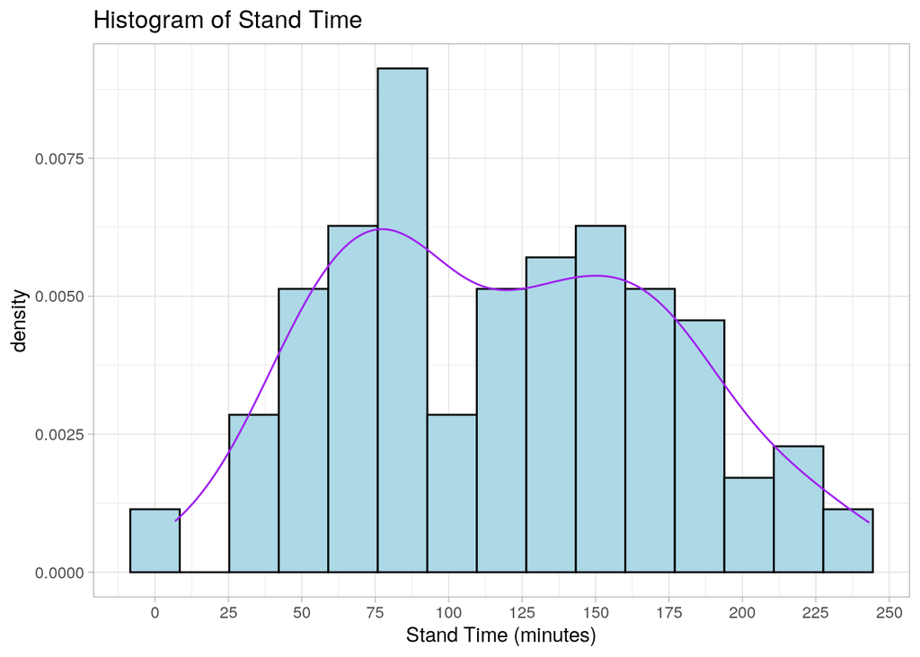

```r
Combined %>% ggplot(aes(x = Stand_Time)) + geom_histogram(aes(y = ..density..,
    ), bins = 15, color = "black", fill = "light blue") + geom_density(color = "purple") +
    xlab("Stand Time (minutes)") + scale_x_continuous(breaks = seq(0,
    250, 25)) + ggtitle("Histogram of Stand Time") + theme_light()
```

This histogram visualizes the distribution of my stand times. Looking at my graph, my most frequent stand time is 75-100 minutes a day and my lowest are at the extremes around 0 minutes and 250 minutes. In addition, my graph is slightly bimodal and has a big peak at ~80 minutes and a smaller peak at ~150 minutes.

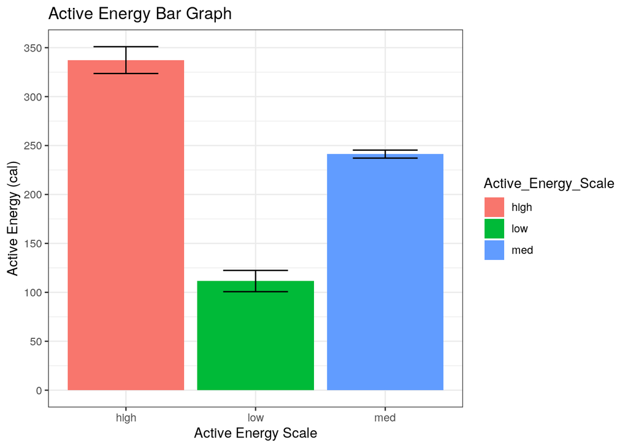

```r
Combined %>% drop_na(Active_Energy_Scale) %>% ggplot(aes(x = Active_Energy_Scale,
    y = Active_Energy)) + geom_bar(aes(y = Active_Energy, fill = Active_Energy_Scale),
    stat = "summary", fun = mean) + geom_errorbar(stat = "summary",
    fun.data = mean_se, width = 0.5) + xlab("Active Energy Scale") +
    ylab("Active Energy (cal)") + ggtitle("Active Energy Bar Graph") +
    scale_y_continuous(breaks = seq(0, 400, 50)) + theme_bw()
```

In this graph, I grouped my Active Energies in groups of high (300+ calories burned), medium (200-300 calories burned) and low (less than 200 calories burned) and visualized the means of each category. Looking at my graph, I can see that for a high level workout, I burn on average ~330 calories, for a medium level workout, I burned on average ~240 calories, and for a low level workout, I burn on average ~115 calories. In addition, looking at the error bars I can see that for high workouts, there is the highest uncertainty and for medium workouts, we have the lowest uncertainty.